# Analyses qualitatives avec R

SB

03/09/2020

```r
knitr::opts_chunk$set(echo = TRUE)
library(readxl)
library(tidyverse)
library(quanteda)
```

```r
library(quanteda.textstats)
library(quanteda.textplots)
```

# 1 Introduction

Dans un premier temps, nous allons tout simplement chargé la base de données de travail, puis la décrire. Ensuite, nous créerons un corpus, le visualisons. Puis nous effectueront quelques analyses liminaires, avant de voir les pré-traitements à réaliser sur le corpus.

## 1.1 Les données

```r
#On charge les données, stockées dans un fichier csv
data<-read_excel("data_airbnb_sample.xlsx")
```

```
## * `` -> ...1
```

```r
#Résumé des données
summary(data)
```

```
##       ...1             X1                X1_1            listing_id
##  Min.   :   1.0   Length:1000        Length:1000        Length:1000
##  1st Qu.: 250.8   Class :character   Class :character   Class :character
##  Median : 500.5   Mode  :character   Mode  :character   Mode  :character
##  Mean   : 500.5
##  3rd Qu.: 750.2
##  Max.   :1000.0
##       id                date           reviewer_id        reviewer_name
##  Length:1000        Length:1000        Length:1000        Length:1000
##  Class :character   Class :character   Class :character   Class :character
##  Mode  :character   Mode  :character   Mode  :character   Mode  :character
##
##
##
##    comments           recence             langue             nbcar
##  Length:1000        Length:1000        Length:1000        Length:1000
##  Class :character   Class :character   Class :character   Class :character
##  Mode  :character   Mode  :character   Mode  :character   Mode  :character
##
##
##
```

```r
data$nbcar<-nchar(data$comments)
summary(data$nbcar)
```

```
##    Min. 1st Qu.  Median    Mean 3rd Qu.    Max.
##     2.0    91.0   162.5   203.6   268.2  1559.0
```

## 1.2 Premières observations du corpus

Tout d’abord, nous transformons le jeu de données en corpus. La variable qui contient le texte est “comments”, les autres variables vont devenir des métadonnées du corpus, c’est-à-dire des variables associées à chaque texte. Cela sera utile par le suite pour faire des analyses comparatives entre les textes suivant différentes variables (le temps en particulier, mais pas seulement).

```r
#Création du corpus
corpus_airbnb<-corpus(data, text_field = "comments")
corpus_airbnb
```

```
## Corpus consisting of 1,000 documents and 11 docvars.
## text1 :
## "J'ai passé 2 semaines dans ce studio chaleureux, aux allures..."
##
## text2 :
## "C’est la deuxième fois que j’occupe ce joli appartement. Not..."
##
## text3 :
## "Appartement très fonctionnel et bien situé dans un quartier ..."
##
## text4 :
## "Logement parfaitement conforme à la description, parfaitemen..."
##
## text5 :
## "Appartement très agréable, baigné de lumière avec une superb..."
##
## text6 :
## "C'est un appartement très clair et très agréable.... Un peti..."
##
## [ reached max_ndoc ... 994 more documents ]
```

```r
corpus_airbnb["text600"] #pour visualiser un texte précis
```

```
## Corpus consisting of 1 document and 11 docvars.
## text600 :
## "Appartement cosy, propre et calme. Idéal pour se poser au mi..."
```

Ensuite, nous allons extraire de chaque texte les termes qui les composent. Ces termes sont nommés “token” (jeton), et comme vous pouvez le voir, ce ne sont pas uniquement des mots, mais tout caractère ou suite de caractères séparés des autres par un espace.

```r
#Extraction des tokens
tok<-tokens(corpus_airbnb)
tok["text600"]
```

```
## Tokens consisting of 1 document and 11 docvars.
## text600 :
##  [1] "Appartement" "cosy"        ","           "propre"      "et"
##  [6] "calme"       "."           "Idéal"       "pour"        "se"
## [11] "poser"       "au"
## [ ... and 6 more ]
```

```r
#Transformation en document-term frequency matrix
dfm<-dfm(tok)
dfm
```

```
## Document-feature matrix of: 1,000 documents, 3,799 features (99.23% sparse) and 11 docvars.
##        features
## docs    j'ai passé 2 semaines dans ce studio chaleureux , aux
##   text1    1     1 1        1    1  3      2          1 2   1
##   text2    0     0 0        0    0  1      0          0 1   0
##   text3    0     0 0        0    1  0      0          0 0   0
##   text4    0     0 0        0    0  0      0          0 1   0
##   text5    0     0 0        0    0  0      0          0 2   0
##   text6    0     0 0        0    0  0      0          0 0   0
## [ reached max_ndoc ... 994 more documents, reached max_nfeat ... 3,789 more features ]
```

Enfin, nous pouvons avoir un aperçu des termes les plus fréquents. Nous les visualisons d’abord sous forme de tableau (les 20 tokens les plus fréquents), puis sous la forme d’un nuage de mots, où la taille des mots correspond à leur fréquence dans le corpus.

```r
#Visualisation des termes les plus fréquents
textstat_frequency(dfm, n=20) #les 20 premiers termes les plus fréquents
```

```
##          feature frequency rank docfreq group
## 1              .      2450    1     826   all
## 2              ,      1606    2     661   all
## 3             et      1400    3     735   all
## 4           très      1166    4     657   all
## 5             de      1075    5     500   all
## 6              à       793    6     461   all
## 7            est       783    7     446   all
## 8             un       586    8     426   all
## 9              !       585    9     367   all
## 10          bien       553   10     429   all
## 11            la       543   11     343   all
## 12            le       510   12     324   all
## 13          pour       464   13     351   all
## 14          nous       432   14     227   all
## 15   appartement       409   15     383   all
## 16             a       351   16     242   all
## 17          dans       332   17     259   all
## 18        séjour       328   18     305   all
## 19 l'appartement       283   19     234   all
## 20            je       280   20     243   all
```

[figure not shown]

```r
textplot_wordcloud(dfm) #nuage de mots
```

Pour conclure sur cette première approche du corpus, nous voyons que nos analyses sont gếnées par la présence de la ponctuation et de plein de petits mots “vides de sens” (les articles par exemple). C’est pourquoi nous allons nettoyer le corpus pour avoir une meilleure vision de ce qu’il contient.

# 2 Nettoyage du corpus

Le nettoyage du corpus pour les analyses se fait lors de la transformation en tokens. Nous allons ajouter des options pour supprimer la ponctuation, les chiffres et les stopwords (les mots qui n’apportent pas de sens sémantique mais permettent l’articulation du discours).

```r
tok<-tokens(corpus_airbnb, remove_punct = TRUE, remove_numbers = TRUE)%>%
  tokens_remove(stopwords("fr"))
tok
```

```
## Tokens consisting of 1,000 documents and 11 docvars.
## text1 :
##  [1] "J'ai"         "passé"        "semaines"     "studio"       "chaleureux"
##  [6] "allures"      "chalet"       "montagne"     "Véronique"    "hôte"
## [11] "accueillante" "attentionnée"
## [ ... and 8 more ]
##
## text2 :
##  [1] "C'est"         "deuxième"      "fois"          "j'occupe"
##  [5] "joli"          "appartement"   "hôte"          "très"
##  [9] "disponible"    "l'appartement" "spacieux"      "tres"
## [ ... and 1 more ]
##
## text3 :
##  [1] "Appartement" "très"        "fonctionnel" "bien"        "situé"
##  [6] "quartier"    "agréable"    "Lucien"      "écoute"      "peux"
## [11] "rendre"      "disponible"
## [ ... and 6 more ]
##
## text4 :
##  [1] "Logement"     "parfaitement" "conforme"     "description"  "parfaitement"
##  [6] "équipé"       "souci"        "détails"      "rendant"      "séjour"
## [11] "agréable"     "Hôte"
## [ ... and 5 more ]
##
## text5 :
##  [1] "Appartement" "très"        "agréable"    "baigné"      "lumière"
##  [6] "superbe"     "vue"         "toits"       "Paris"       "Lara"
## [11] "top"         "très"
## [ ... and 2 more ]
##
## text6 :
##  [1] "C'est"       "appartement" "très"        "clair"       "très"
##  [6] "agréable"    "petit"       "bémol"       "forte"       "odeur"
## [11] "cigarette"   "peignoirs"
## [ ... and 6 more ]
##
## [ reached max_ndoc ... 994 more documents ]
```

Ensuite, on transforme en dfm et on visualise ce que ça donne.

```r
dfm<-dfm(tok)

textstat_frequency(dfm, n=20)
```

```
##          feature frequency rank docfreq group
## 1           très      1166    1     657   all
## 2           bien       553    2     429   all
## 3    appartement       409    3     383   all
## 4              a       351    4     242   all
## 5         séjour       328    5     305   all
## 6  l'appartement       283    6     234   all
## 7          situé       267    7     262   all
## 8       agréable       259    8     242   all
## 9          calme       244    9     239   all
## 10          tout       239   10     198   all
## 11      quartier       203   11     189   all
## 12        propre       190   12     187   all
## 13         paris       177   13     166   all
## 14    recommande       176   14     176   all
## 15      logement       168   15     151   all
## 16           bon       151   16     145   all
## 17         métro       148   17     145   all
## 18         merci       144   18     139   all
## 19         super       126   19     114   all
## 20       parfait       122   20     121   all
```

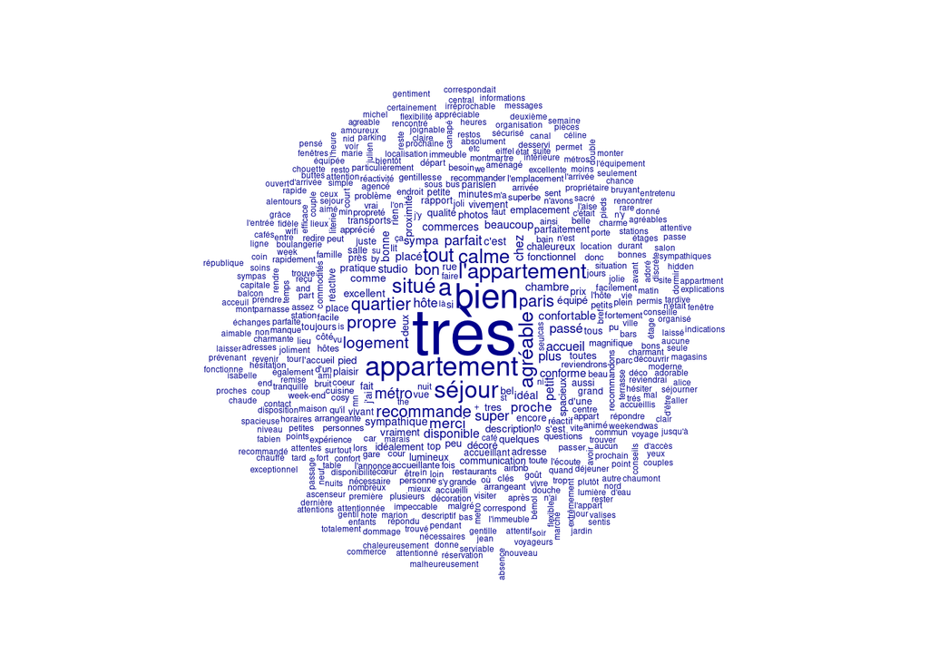

```r
textplot_wordcloud(dfm)
```

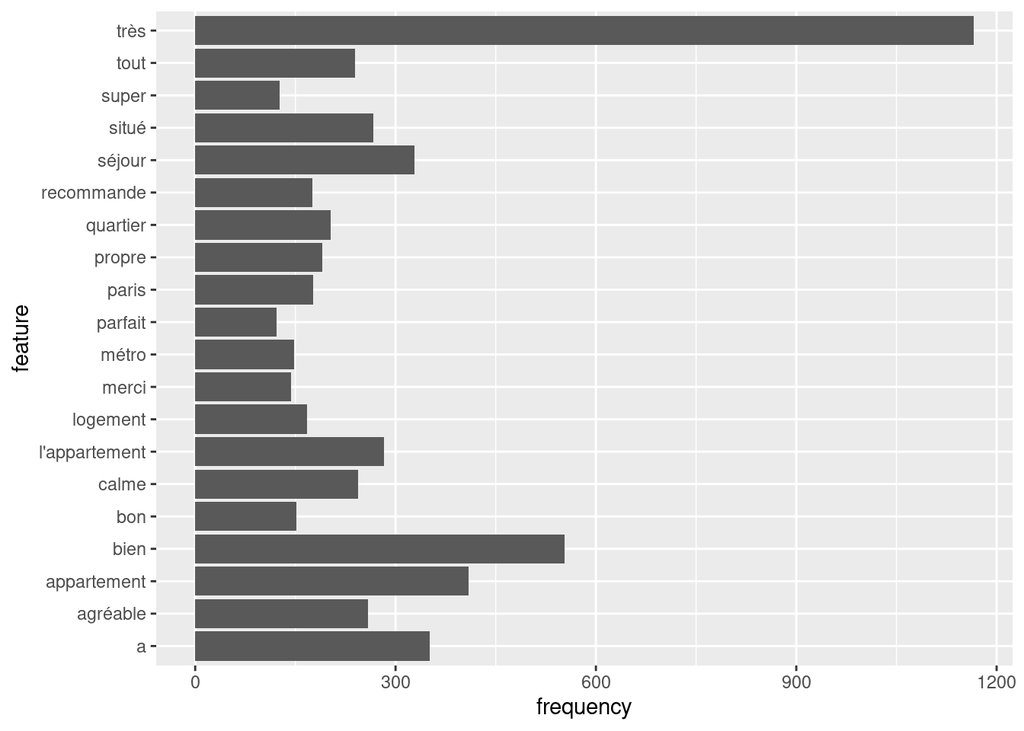

```r
g<-textstat_frequency(dfm,n=20)
ggplot(g, aes(x = feature, y=frequency))+
  geom_col()+
  coord_flip()
```

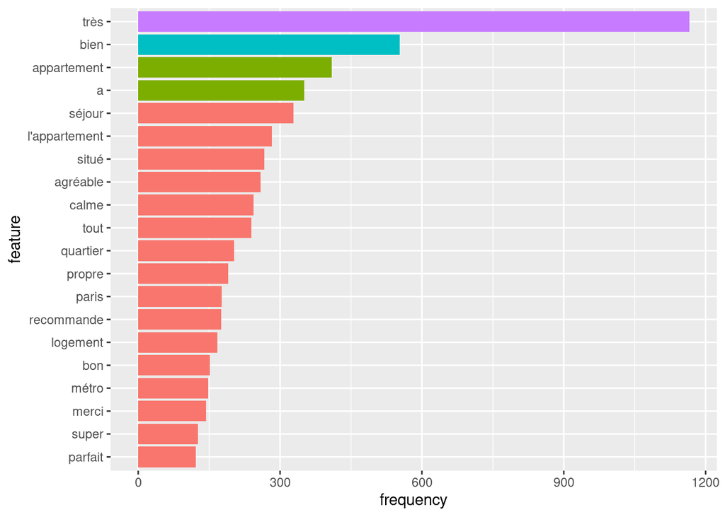

```r
g<-g%>%mutate(feature = factor(feature, levels = rev(unique(feature))))%>%
  mutate(color = cut(frequency, breaks = 5,dig.lab = -1))
ggplot(g, aes(x = feature, y=frequency, fill=color))+
  geom_col(show.legend = FALSE)+
  coord_flip()
```

Globalement, l’appartement et le séjour sont TRÈS bien et agréable. La surreprésentation de ces termes dans le corpus nous empêche de voir les thématiques abordées de manière moins évidentes. Nous avons plusieurs solutions qui s’offrent à nous : filtrer les mots trop fréquents du corpus ou nous intéresser à une autre mesure de la fréquence d’apparition. Nous allons d’abord filtrer le corpus.

On peut aussi vouloir remplacer des termes par d’autres, comme ici “l’appartement” par “appartement”.

```r
tok<-tokens_replace(tok, "l\'appartement", "appartement")
dfm<-dfm(tok)
textstat_frequency(dfm, n=20)
```

```
##        feature frequency rank docfreq group
## 1         très      1166    1     657   all
## 2  appartement       692    2     565   all
## 3         bien       553    3     429   all
## 4            a       351    4     242   all
## 5       séjour       328    5     305   all
## 6        situé       267    6     262   all
## 7     agréable       259    7     242   all
## 8        calme       244    8     239   all
## 9         tout       239    9     198   all
## 10    quartier       203   10     189   all
## 11      propre       190   11     187   all
## 12       paris       177   12     166   all
## 13  recommande       176   13     176   all
## 14    logement       168   14     151   all
## 15         bon       151   15     145   all
## 16       métro       148   16     145   all
## 17       merci       144   17     139   all
## 18       super       126   18     114   all
## 19     parfait       122   19     121   all
## 20      proche       111   20     102   all
```

# 3 Filtrer le coprus des termes trop fréquents

Nous allons filtrer les mots qui sont présents plus de 200 fois dans le corpus.

```r
dfm_trim<-dfm_trim(dfm, max_termfreq = 200)

textstat_frequency(dfm_trim, n=20)
```

```
##        feature frequency rank docfreq group
## 1       propre       190    1     187   all
## 2        paris       177    2     166   all
## 3   recommande       176    3     176   all
## 4     logement       168    4     151   all
## 5          bon       151    5     145   all
## 6        métro       148    6     145   all
## 7        merci       144    7     139   all
## 8        super       126    8     114   all
## 9      parfait       122    9     121   all
## 10      proche       111   10     102   all
## 11        hôte       106   11     105   all
## 12        plus       104   12      89   all
## 13     accueil       104   12     103   all
## 14       passé       103   14     101   all
## 15        chez        97   15      91   all
## 16  disponible        91   16      91   all
## 17       petit        90   17      85   all
## 18       sympa        83   18      79   all
## 19 confortable        81   19      80   all
## 20     chambre        75   20      67   all
```

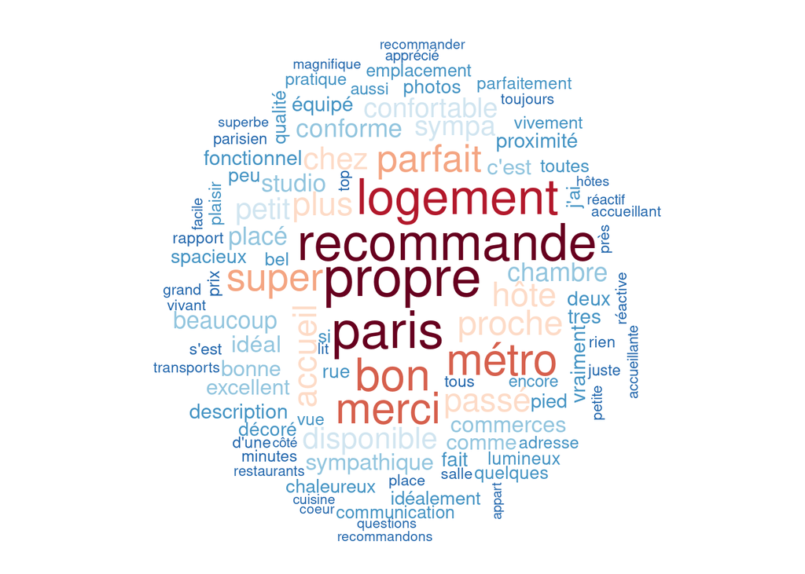

```r
textplot_wordcloud(dfm_trim, max_words = 100, color = rev(RColorBrewer::brewer.pal(10, "RdBu")))
```

Une autre manière de s’y prendre est d’éliminer directement les termes que l’on ne veut pas voir apparaître.

```r
textstat_frequency(dfm,n=20)
```

```
##        feature frequency rank docfreq group
## 1         très      1166    1     657   all
## 2  appartement       692    2     565   all
## 3         bien       553    3     429   all
## 4            a       351    4     242   all
## 5       séjour       328    5     305   all
## 6        situé       267    6     262   all
## 7     agréable       259    7     242   all
## 8        calme       244    8     239   all
## 9         tout       239    9     198   all
## 10    quartier       203   10     189   all
## 11      propre       190   11     187   all
## 12       paris       177   12     166   all
## 13  recommande       176   13     176   all
## 14    logement       168   14     151   all
## 15         bon       151   15     145   all
## 16       métro       148   16     145   all
## 17       merci       144   17     139   all
## 18       super       126   18     114   all
## 19     parfait       122   19     121   all
## 20      proche       111   20     102   all
```

```r
rem<-c("très","bien","appartement","a", "séjour", "l'appartement", "situé", "agréable", "calme", "tout", "quartier")

dfm_rem<-dfm_remove(dfm, rem)
textstat_frequency(dfm_rem, n=20)
```

```
##        feature frequency rank docfreq group
## 1       propre       190    1     187   all
## 2        paris       177    2     166   all
## 3   recommande       176    3     176   all
## 4     logement       168    4     151   all
## 5          bon       151    5     145   all
## 6        métro       148    6     145   all
## 7        merci       144    7     139   all
## 8        super       126    8     114   all
## 9      parfait       122    9     121   all
## 10      proche       111   10     102   all
## 11        hôte       106   11     105   all
## 12        plus       104   12      89   all
## 13     accueil       104   12     103   all
## 14       passé       103   14     101   all
## 15        chez        97   15      91   all
## 16  disponible        91   16      91   all
## 17       petit        90   17      85   all
## 18       sympa        83   18      79   all
## 19 confortable        81   19      80   all
## 20     chambre        75   20      67   all
```

# 4 La loi de Zipf

Vérifions la proposition de la loi de Zipf, selon laquelle la fréquence d’apparition d’un terme est inversement proportionnel à son rang.

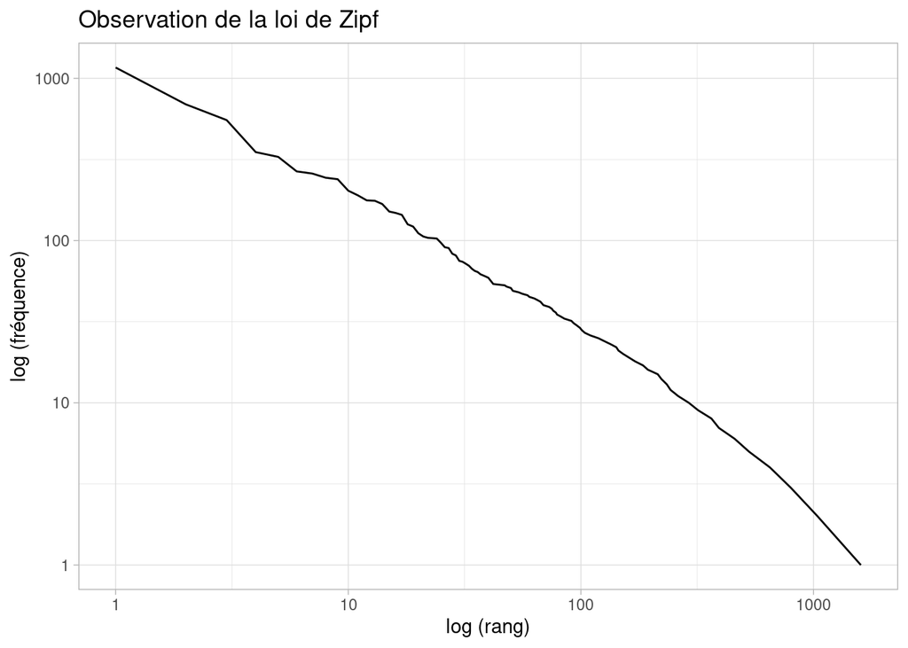

```r
zipf<-textstat_frequency(dfm)
ggplot(zipf, aes(rank, frequency))+
  geom_line()+
   scale_x_log10() +
  scale_y_log10()+
  theme_light()+
  labs(title = "Observation de la loi de Zipf",x="log (rang)",y="log (fréquence)")
```

# 5 Comprendre le sens des termes

On peut visualiser un ou plusieurs termes dans leur contexte, afin d’avoir une meilleure compréhension de leur sens. Pour cela on utilise la fonction “kwic” pour key word in context, à partir de l’objet tokens :

```r
kwic(tok, c("cuisine", "douche"))
```

```
## Keyword-in-context with 43 matches.
##   [text14, 21]                      aussi bien salle bains comme | cuisine |
##   [text16, 24]                  bruit qu'il fait bruit chaudière | cuisine |
##   [text26, 22]    sympathique lieu propre Possibilité d'utiliser | cuisine |
##   [text28, 14]                 Accueil froid sentie l'aise Accès | cuisine |
##    [text40, 6]           Lieu très accueillant chaleureux Espace | cuisine |
##   [text65, 15]          décrit problème d'odeur d'humidité salle | douche  |
##  [text168, 21]            bien chauffé bien isolé phonétiquement | Cuisine |
##  [text168, 23]           bien isolé phonétiquement Cuisine salle | douche  |
##  [text205, 18]                      Très déçue l'état salle bain | douche  |
##  [text213, 77]               personnes problème WC séparés salle | douche  |
##  [text213, 79]                     WC séparés salle douche salle | douche  |
##  [text252, 27]                      aimé qu'il mieux fournis gel | douche  |
##  [text254, 33]               difficulté m'a aussi proposé servir | cuisine |
##  [text267, 45]       manger pouvant accueillir jusqu'à personnes | cuisine |
##  [text308, 28]             bonheur prendre petit déjeuner balcon | cuisine |
##   [text388, 9]               joliment décoré dispose d'une belle | cuisine |
##  [text389, 18]               papiers traînent partout micro onde | cuisine |
##  [text409, 19]                    décoration top fan table basse | cuisine |
##  [text424, 48]     là personnellement tout parfaitement organisé | cuisine |
##   [text535, 4]                     Logement conforme description | cuisine |
##   [text558, 3]                              Manque d'équipements | cuisine |
##  [text559, 18]     malheureusement souci plomberie d'apres hôtes | douche  |
##   [text564, 7]  charmant calme conforme description L'équipement | cuisine |
##  [text592, 37]    WIFI microondes-four cafetière tous ustensiles | cuisine |
##  [text618, 31]                 tapis sale cuvette wc défectueuse | douche  |
##  [text625, 40]          bémol baignoire gagnerait être remplacée | douche  |
##  [text657, 18]                  paradis vraiment top beau séjour | cuisine |
##   [text662, 8]        plein cœur marais emplacement exceptionnel | Cuisine |
##   [text670, 5]              Appartement fonctionnel trop chauffé | cuisine |
##   [text686, 6] appartement parfait personnes décoration chouette | cuisine |
##  [text696, 13]            plus trois personnes Baignoire bouchée | cuisine |
##  [text731, 19]                     Studio propre bien aménagé si | douche  |
##  [text750, 36]                      a plus place s'asseoir salle | douche  |
##  [text750, 49]           personnes appartement plus grande pièce | cuisine |
##  [text759, 12]                     superbe vue Montmartre vrai + | cuisine |
##  [text785, 13]              passante Lit très confortable grande | douche  |
##  [text788, 40]        fait départ comme l'arrivée l'installation | cuisine |
##   [text799, 9]              placé literie très confortable vraie | cuisine |
##   [text821, 8]               propre pratique quartier calm Belle | cuisine |
```

[output cut: 33 more lines]

```
##  inexistante Séjour agréable l'ensemble
##  équipée tout qu'il faut cuisiner
##  peu pratique l'hôte arrangeant recommande
##  riquiqui Rapport qualité prix génial
##  toilettes fait m2 Tout fait
##  centre appartement autres pièces trop
##  équipée d'un lave vaisselle literie
##  italienne bonne adresse déjà réservé
##  limite vétusté évier étagère évier
##  équipée Excellent rapport qualité prix
##
##  reste impeccable
##  rien dramatique
##  shampoing autre dispo l'arrivée c'est
##  l'italienne Merci accueil réactivité très
```

```r
# kwic(tok, "très", window=10)
```

# 6 Fabriquer un corpus directement via R

Il existe différentes méthodes pour constituer un corpus : on peut en récolter des existants directement en ligne (ex: [InsideAirbnb](https://insideairbnb.com)), utiliser la bonne vieille méthode du copier-coller, ou encore utiliser des programmes informatiques, appelés scraper (ex : [DataMiner](https://data-miner.io/) ou [ParseHub](https://www.parsehub.com/)). On peut aussi en constituer directement via R.

Pour constituer un corpus directement via R, on utilise les API proposés par deux plateformes, Twitter et Facebook. On ne fait pas tourner le code, c’est un peu long et il faut disposer d’un compte développeur sur chacune des deux plateformes.

```r
# library(rtweet)
#
# x<-c("#Etam") #les termes cibles
#
# tweets <- search_tweets(x,n=200000,retryonratelimit = TRUE)
#
# write_rds(tweets, "mon_nom_de_fichier.rds")
```

```r
# library(Rfacebook)
#
# fb_connection <-   fbOAuth(app_id     = "your_app_id",
#                        app_secret = "your_app_secret")
# fb_connection
#
#
# page<-getPage("Etam", token=fb_connection)
#
#write_rds(page, "mon_nom_de_fichier.rds")
```